# Droplasso vs Glmnet on simulated data

Jean-Philippe Vert

2018-11-06

# Introduction

`droplasso` is a package that fits a generalized linear model via maximum likelihood regularized by droplasso (Khalfaoui and Vert 2018), a procedure that combines dropout (Srivastava et al. 2014) and lasso (Tibshirani 1996) regularizations.

Given a training set of samples $x_1,\ldots,x_n\in\mathbb{R}^d$ with labels $y_1,\ldots,y_n\in\mathbb{R}$, the droplasso regularization estimates a linear model $f(x)=w^\top x$ for $x\in\mathbb{R}^d$ by solving:
$$\begin{equation}
\min_{w \in \mathbb{R}^d} \left\{ \frac{1}{n} \sum_{i=1}^{n} \underset{\delta_i \sim B(p)^d}{ \mathbb {E}} L\left(w,\delta_i \odot \frac{x_{i,}}{p} , y_{i} \right) + \lambda \left \| w\right \|_{1} \right\} \,,
\end{equation}$$

where $L(w,x,y)$ is a negative log likelihood of a linear model $w$ on a observation $x$ with label $y$, $B(p)$ is the Bernoulli distribution with parameter $p$, and $\odot$ is the entry-wise multiplication of vectors. When $p=1$, each $\delta_i$ is almost surely a vector of $1$’s and droplasso boils down to classical lasso; and when $\lambda=0$, droplasso boils down to dropout.

# Data simulation

Here we illustrate the use of droplasso on simulated data, and compare it to standard dropout and elastic net regularisation. We design a toy simulation to illustrate in particular how corruption by dropout noise impacts the performances of the different methods. The simulation goes as follow :

- We set the dimension to $d=100$.
- Each sample is a random vector $z\in\mathbb{N}^d$ with entries following a Poisson distribution with parameter $\pi=1$. We introduce correlations between entries by first sampling a Gaussian copula with covariance $\Sigma_d = \mathbf{I}_d + \mathbf{1}_{d}^{\top} \mathbf{1}_d$, then transforming each entry in $[0,1]$ into an integer using the Poisson quantile function.
- The ``true’’ model is a logistic model with sparse weight vector $w\in\mathbb{R}^d$ satisfying $w_i=0.05$ for $i=1,\ldots,10$ and $w_i=0$ for $i=11,\ldots,d.$
- Using $w$ as the true underlying model and $z$ as the true observations, we simulate a label $y \sim B( 1/(1+\exp(-w^\top z )) )$
- We introduce corruption in the samples by dropout events by multiplying entry-wise $z$ with an i.i.d Bernoulli variables $\delta$ with probability $q=0.4$.

Let us simulate $n=100$ samples to form the training set, and $10,000$ samples to test the model:

```r
library(mvtnorm)
generate_data <- function(n=100, d=100, d1=10, pi=1, w=0.05, q=0.4) {
  # The samples z
  mu <- rep(0,d)
  Sigma <- (matrix(1, nrow=d, ncol=d)  + diag(d))/2
  rawvars <- rmvnorm(n, mean=mu, sigma=Sigma)
  pvars <- pnorm(rawvars)
  z  <- qpois(pvars, pi)
  # The sparse model w
  w <-c(rep(w,d1),rep(0,d-d1))
  # The labels y
  y <- rbinom(n, 1, 1/(1+exp(-z %*%  w)) )
  # The corrupted samples x
  x <- sapply(1:d, function(i) z[,i] * rbinom(n,1,q))
  return(list(z=z, x=x, y=y, w=w))
}
data_train <- generate_data()
data_valid <- generate_data(n=10000)
data_test <- generate_data(n=10000)
```

# Droplasso

Let us illustrate how to fit a Droplasso model and test it.

## Droplasso for a given $p$

Let us train a droplasso model with default parameter ($p$=0.5) for a binary classification problem (i.e., using the logistic loss function). The function `droplasso` allows to directly fit the model over a grid of $\lambda$ to estimate the regularization path, so here we compute the regularization path over 50 values of $\lambda$:

```r
library(droplasso)
m <- droplasso(data_train$x, data_train$y, family="binomial", nlambda=50)
```

Since we did not speficy a value for the regularization parameter $\lambda$, the function has computed all droplasso models over a grid of $\lambda$. We can visualize the resulting regularization path, i.e., the model weights as a function of $\lambda$:

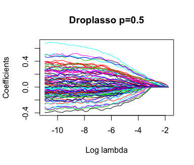

```r
plot(m, main="Droplasso p=0.5")
```

Let us see what the model predicts on the test set (for all $\lambda$ values)

```r
ypred <- predict(m, data_test$x)
```

Since we know the true labels, we can compute the area under the ROC curve (AUC) to evaluate the quality of the predictions

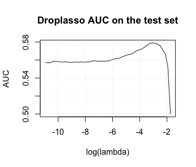

```r
library(ROCR)
pred <- sapply(seq(ncol(ypred)), function(j) {prediction(ypred[,j], data_test$y)})
auc <- unlist(lapply(pred, function(p) {performance(p, "auc")@y.values[[1]]}))
plot(log(m$lambda), auc, type='l', xlab="log(lambda)", ylab="AUC", main="Droplasso AUC on the test set")
grid()
```

We see that, as $\lambda$ decreases and the model goes from the null model to models with more variables, the AUC sharply increases and then decreases, which illustrates the benefits of regularization.

## Varying $p$

So far we have only tested droplasso with the default dropout parameter $p$ set to 0.5 . However, $p$ also is also a regularization parameter that we can tune between 0 (high regularization) and 1 (no regularization). Note that when $p$ is small, the optimization is more challenging and it may be useful to increase the number of epoch of the proximal stochastic gradient descent algorithm by playing with the `n_passes` parameter of the `droplasso` function.

Let us see how the performance varies when we vary $p$. Since the convergence of the optimization is harder to reach for small values of $p$, the performance is subject to more fluctuation. In order to pick the “best” AUC, we therefore use a validation set to select the “best” $\lambda$, and then assess the AUC of that particular $\lambda$ only on the test set.

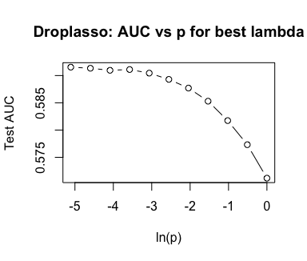

```r
# The values of p we want to test
probalist <- 0.6^seq(0,10)
# The number of lambda values we want to test to form the regularization path
nlambda <- 100
# The number of epoch of the optimization procedure
n_passes = 10000

auclist <- c()
for (proba in probalist) {
  # Train on the train set
  m <- droplasso(data_train$x, data_train$y, family="binomial", keep_prob=proba, nlambda=nlambda, n_passes = n_passes)
  # Pick lambda with the best AUC on the validation set
  ypred <- predict(m, data_valid$x)
  pred <- sapply(seq(ncol(ypred)), function(j) {prediction(ypred[,j], data_valid$y)})
  auc <- unlist(lapply(pred, function(p) {performance(p, "auc")@y.values[[1]]}))
  bestlambda <- m$lambda[which.max(auc)]
  # Assess AUC of the best lambda on the test set
  ypred <- predict(m, data_test$x, s=bestlambda)
  auc <- performance(prediction(ypred, data_test$y), "auc")@y.values[[1]]
  auclist <- c(auclist,auc)
}
plot(log(probalist), auclist, type='b', xlab='ln(p)', ylab='Test AUC', main='Droplasso: AUC vs p for best lambda')
```

# Comparison of Droplasso and Glmnet

As explained in (Khalfaoui and Vert 2018), droplasso is related to elastic net regularization (Zou and Hastie 2005). Let us check how elastic net behaves on the same dataset.

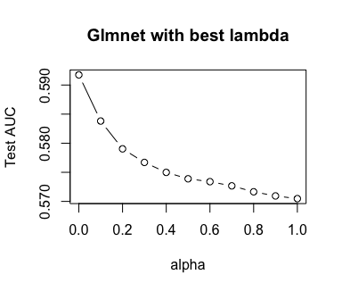

```r
library(glmnet)
# The values of alpha to interpolate between lasso (alpha=1) and ridge (alpha=0)
alphalist <- seq(0,1,0.1)
auclist <- c()
firstalpha <- TRUE
for (alpha in alphalist) {
  # Train glmnet model
  m_glm <- glmnet(data_train$x, data_train$y, family="binomial", intercept=F, alpha=alpha, standardize = F, nlambda=nlambda)
  # Predict on the validation set
  ypred <- data_valid$x %*% m_glm$beta
  pred <- sapply(seq(ncol(ypred)), function(j) {prediction(ypred[,j], data_valid$y)})
  auc <- unlist(lapply(pred, function(p) {performance(p, "auc")@y.values[[1]]}))
  if (length(auc) < nlambda) { # glmnet did not converge for the last lambda values
    auc <- c(auc, rep(0.5, nlambda-length(auc)))
  }
  if (firstalpha) {
    auc_el <- auc
    firstalpha <- FALSE
  } else {
    auc_el <- cbind(auc_el, auc)
  }

  # Assess AUC of the best lambda on the test set
  bestlambdaindex <- which.max(auc)
  ypred <- data_test$x %*% m_glm$beta[,bestlambdaindex]
  auc <- performance(prediction(ypred, data_test$y), "auc")@y.values[[1]]
  auclist <- c(auclist,auc)
}
plot(alphalist, auclist[1:11], type='b', xlab='alpha', ylab='Test AUC', main='Glmnet with best lambda')
```

We see that, similar to droplasso, glmnet works best when there is no lasso regularization, and a lot of ridge regularization, as shown on the following plot which details the performance of glmnet for various lambda and alpha.

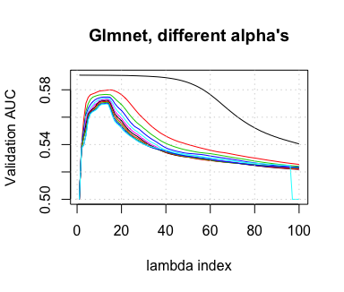

```r
matplot(auc_el, type='l', lty=1, xlab='lambda index', ylab='Validation AUC', main="Glmnet, different alpha's", legend=alphalist)
grid()
```

The best curve is for `alpha=0` (ridge regression), and the best values for large $\lambda$ (left of the plot).

# References

Khalfaoui, B., and J.-P. Vert. 2018. “DropLasso: A Robust Variant of Lasso for Single Cell RNA-Seq Data.” 01716704. HAL.

Srivastava, N., G. Hinton, A. Krizhevsky, I. Sutskever, and R. Salakhutdinov. 2014. “Dropout: A Simple Way to Prevent Neural Networks from Overfitting.” *J. Mach. Learn. Res.* 15 (1). JMLR. org: 1929–58.

Tibshirani, R. 1996. “Regression Shrinkage and Selection via the Lasso.” *J. R. Stat. Soc. Ser. B* 58 (1): 267–88. http://www.jstor.org/stable/2346178.

Zou, H., and T. Hastie. 2005. “Regularization and Variable Selection via the Elastic Net.” *J. R. Stat. Soc. Ser. B* 67: 301–20. http://citeseerx.ist.psu.edu/viewdoc/summary?doi=10.1.1.89.1596.